# 大数据分析与挖掘

## 12. Horovod

主讲人：丁平尖

## Horovod 分布式深度学习训练框架简介

Horovod 是一个由 Uber 开发的分布式深度学习训练框架，支持 TensorFlow、Keras、PyTorch 等主流深度学习库。Horovod 通过高效的通信机制（如 NCCL、MPI），实现多 GPU/多节点间的梯度同步，大幅提升模型训练速度和扩展性。

主要特点：

- **易于集成**：只需少量代码修改即可将现有模型扩展为分布式训练 。
- **高性能**：采用环形 AllReduce 算法，显著减少通信开销。
- **支持多平台**：可在本地、云端、Spark 集群等多种环境部署。
- **与 Spark 集成**：Horovod on Spark 支持大规模数据分布式训练，适合大数据场景。

常见应用场景包括大规模图像分类、自然语言处理、推荐系统等。更多信息可参考 [Horovod 官方文档](https://horovod.readthedocs.io/en/stable/)。

## PySpark 和 Horovod 示例

论文 [NoRBERT: Transfer Learning for Requirements Classification](https://ieeexplore.ieee.org/abstract/document/9218141)（Hey 等人）介绍了使用 BERT 进行需求分类，相关代码见 [Hey 的 GitHub 仓库](https://github.com/tobhey/NoRBERT)。

采用更简洁的 [Keras](https://keras.io/) 实现方式（而非 [PyTorch](https://pytorch.org)）

推荐以下资源帮助理解代码实现思路：

- [Multi-class Text Classification using BERT and TensorFlow](https://towardsdatascience.com/multi-label-text-classification-using-bert-and-tensorflow-d2e88d8f488d)
- [TensorFlow 教程](https://youtu.be/5Ym-dOS9ssA)（Keras 与深度学习入门）
- [使用 BERT 进行文本分类](https://www.tensorflow.org/text/tutorials/classify_text_with_bert)（Keras 官方教程）
- [BERT 文本分类 Colab 示例](https://colab.research.google.com/github/tensorflow/text/blob/master/docs/tutorials/classify_text_with_bert.ipynb)

Spark 分布式训练 Horovod 相关资源：

- [Horovod on Spark](https://github.com/horovod/horovod/blob/master/docs/spark.rst)
- [Horovod 与 Keras](https://github.com/horovod/horovod/blob/master/docs/keras.rst)
- [Databricks 示例笔记本](https://docs.databricks.com/machine-learning/train-model/distributed-training/horovod-spark.html)
- [TensorFlow_model](https://www.tensorflow.org/static/site-assets/images/marketing/resources/models-hero.svg)

## Keras 简介

Keras 是一个高级神经网络 API，支持快速构建和训练深度学习模型。它最初由 François Chollet 开发，现已成为 TensorFlow 的官方高级接口。Keras 具有以下特点：

- **易用性**：采用简洁、直观的 API，便于快速原型设计和实验。
- **模块化**：模型、层、优化器等均为独立模块，可灵活组合。
- **支持多种后端**：最初支持 TensorFlow、Theano、CNTK，现主要集成于 TensorFlow。
- **丰富的社区资源**：拥有大量教程、示例和预训练模型。

Keras 适用于从入门到工业级的深度学习应用，包括图像识别、文本处理、时间序列分析等。更多信息可参考 [Keras 官方文档](https://keras.io/)。

## 依赖项

- 在使用 GPU 时性能会更好。
- 相关模型
  - tensorflow, BERT and other models
- numpy、sklearn、tensorflow 等库
- tensorflow-text：TensorFlow 的文本处理扩展库，提供分词、正则化、编码等自然语言处理工具，常用于 BERT 等模型的文本预处理，支持多语言和复杂文本操作。
- tf-models-official：TensorFlow 官方模型库，包含大量预训练模型和标准实现（如BERT、ResNet、EfficientNet等），便于快速复现论文、微调和部署深度学习模型。
- tensorrt：NVIDIA 推出的高性能深度学习推理优化库，支持 TensorFlow/PyTorch 等模型的加速部署，主要用于 GPU 上的模型压缩、量化和高效推理，显著提升推理速度和资源利用率。

```
pip install tensorflow==2.12 tensorflow-text tf-models-official tensorrt numpy==1.22 pandas==1.5.3 seaborn
```

```python
from importlib.metadata import version
print(f"Tensorflow {version('tensorflow')}")
print(f"numpy {version('numpy')}")
print(f"pandas {version('pandas')}")
print(f"matplotlib {version('matplotlib')}")
```

```
Tensorflow 2.12.0
numpy 1.22.0
pandas 1.5.3
matplotlib 3.8.4
```

```python
import warnings
warnings.filterwarnings("ignore")
# 导入所需的库和设置参数
import os
import shutil
import numpy as np
import pandas as pd
import tensorflow as tf
import tensorflow_hub as hub
import tensorflow_text as text
from tensorflow import keras
import matplotlib.pyplot as plt
tf.get_logger().setLevel('ERROR')
# print display options
pd.options.display.max_columns = None
pd.options.display.width=None
np.set_printoptions(linewidth=160)
```

# 数据集

数据集 promise_nfr.csv 来源于 NoRBERT 项目，包含软件需求的文本及其标签。每条数据是一条需求说明（RequirementText），并标注了其所属类别（clazz）和是否为非功能性需求（NFR）。

```python
!wget -nc https://raw.githubusercontent.com/tobhey/NoRBERT/master/Code/Task1_to_3_original_Promise_NFR_dataset/promise_nfr.csv
```

```
--2025-11-25 06:41:23--  https://raw.githubusercontent.com/tobhey/NoRBERT/master/Code/Task1_to_3_original_Promise_NFR_dataset/promise_nfr.csv
Resolving raw.githubusercontent.com (raw.githubusercontent.com)... 2606:50c0:8000::154, 2606:50c0:8003::154, 2606:50c0:8001::154, ...
Connecting to raw.githubusercontent.com (raw.githubusercontent.com)|2606:50c0:8000::154|:443... connected.
HTTP request sent, awaiting response... 200 OK
Length: 97495 (95K) [text/plain]
Saving to: ‘promise_nfr.csv’

promise_nfr.csv     100%[===================>]  95.21K  --.-KB/s    in 0.1s

2025-11-25 06:41:24 (919 KB/s) - ‘promise_nfr.csv’ saved [97495/97495]
```

```python
# 加载并预处理数据集
import pandas as pd
def load_data(filename):
    print(filename)
    df = pd.read_csv(filename, delimiter=';', header=0, encoding='utf8', names=['number', 'ProjectID', 'RequirementText', 'clazz', 'NFR', 'F', 'A', 'FT', 'L', 'LF', 'MN', 'O', 'PE', 'PO', 'SC', 'SE', 'US'])
    df = df.dropna()
    # 只保留 NFR 为 1 的数据行
    is_NFR = df['NFR']==1
    df = df[is_NFR]
    return df
pdf = load_data("promise_nfr.csv")
```

```
promise_nfr.csv
```

```python
pdf.head()
```

|  | number | ProjectID | RequirementText | clazz | NFR | F | A | FT | L | LF | MN | O | PE | PO | SC | SE | US |
| --- | --- | --- | --- | --- | --- | --- | --- | --- | --- | --- | --- | --- | --- | --- | --- | --- | --- |
| 0 | 1 | 1 | The system shall refresh the display every 60 ... | PE | 1 | 0 | 0 | 0 | 0 | 0 | 0 | 0 | 1 | 0 | 0 | 0 | 0 |
| 1 | 2 | 1 | The application shall match the color of the s... | LF | 1 | 0 | 0 | 0 | 0 | 1 | 0 | 0 | 0 | 0 | 0 | 0 | 0 |
| 2 | 3 | 1 | If projected the data must be readable. On ... | US | 1 | 0 | 0 | 0 | 0 | 0 | 0 | 0 | 0 | 0 | 0 | 0 | 1 |
| 3 | 4 | 1 | The product shall be available during normal ... | A | 1 | 0 | 1 | 0 | 0 | 0 | 0 | 0 | 0 | 0 | 0 | 0 | 0 |
| 4 | 5 | 1 | If projected the data must be understandable... | US | 1 | 0 | 0 | 0 | 0 | 0 | 0 | 0 | 0 | 0 | 0 | 0 | 1 |

```python
# 统计每个类别的样本数量，并计算类别总数
print(pdf.groupby(['clazz'])['clazz'].count())
num_classes = pdf.groupby(['clazz'])['clazz'].count().shape[0]
print(f"Number of classes is {num_classes}")
```

```
clazz
A     21
FT    10
L     13
LF    38
MN    17
O     62
PE    54
PO     1
SC    21
SE    66
US    67
Name: clazz, dtype: int64
Number of classes is 11
```

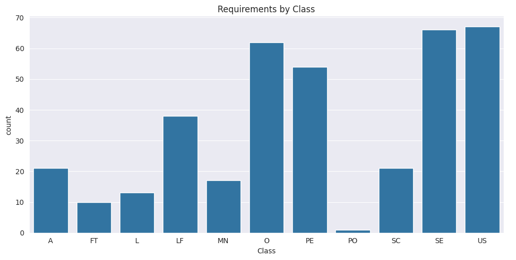

```python
# 统计每个类别的需求数量，并可视化分布
import seaborn as sns
req_counts = pdf.groupby(['clazz'])['clazz'].count()
req_counts_df = pd.DataFrame({'Class':req_counts.index, 'count':req_counts.values})
sns.catplot(data=req_counts_df, x='Class', y='count', kind='bar', height=5, aspect=2).set(title='Requirements by Class');
```

## 复制单例类别的出现次数

将只出现一次的类别（行）进行复制。这样可以实现分层的 n 折验证，因为每个类别至少需要 n 个样本才能进行分层交叉验证。

- 这会引入重复的文本及其对应的类别标签
- 复制 n 次后，总共会有 n+1 个样本，可以进行分层的 n+1 折验证，每一折都能包含该类别的一个样本（与原始数据类似）。

将 `num_min_class` 设置为 `-1` 可使用原始数据集。

```python
# 复制或删除指定类别的行以满足分层交叉验证的需要
# num_min_class > 0 时，复制该类别的行 num_min_class 次
# num_min_class == 0 时，删除该类别的所有行
# num_min_class < 0 时，不做任何处理

num_min_class = 0
col = 'clazz'
value = 'PO'

def replicate_class_rows(df: pd.DataFrame, col='clazz', value='PO', rep_num=3):
  """
  Replicate a row `rep_num` times and add to `df`.
  Applied to only one row to enable n-folds of cross validation.
  The result will be rep_num+1 rows that match the row with value.
  """
  # 选取指定类别的第一行作为复制对象
  rep_row = df.loc[df[col] == value].iloc[0]
  for i in range(0, rep_num):
    df.loc[len(df.index)] = rep_row
  return df

if num_min_class > 0:
  pdf = replicate_class_rows(pdf, col=col, value=value, rep_num=num_min_class)
elif num_min_class == 0:
  # remove the min class row(s)
  pdf = pdf[pdf[col]!=value]
else:
  print("No change to data.")

pdf
```

|  | number | ProjectID | RequirementText | clazz | NFR | F | A | FT | L | LF | MN | O | PE | PO | SC | SE | US |
| --- | --- | --- | --- | --- | --- | --- | --- | --- | --- | --- | --- | --- | --- | --- | --- | --- | --- |
| 0 | 1 | 1 | The system shall refresh the display every 60 ... | PE | 1 | 0 | 0 | 0 | 0 | 0 | 0 | 0 | 1 | 0 | 0 | 0 | 0 |
| 1 | 2 | 1 | The application shall match the color of the s... | LF | 1 | 0 | 0 | 0 | 0 | 1 | 0 | 0 | 0 | 0 | 0 | 0 | 0 |
| 2 | 3 | 1 | If projected the data must be readable. On ... | US | 1 | 0 | 0 | 0 | 0 | 0 | 0 | 0 | 0 | 0 | 0 | 0 | 1 |
| 3 | 4 | 1 | The product shall be available during normal ... | A | 1 | 0 | 1 | 0 | 0 | 0 | 0 | 0 | 0 | 0 | 0 | 0 | 0 |
| 4 | 5 | 1 | If projected the data must be understandable... | US | 1 | 0 | 0 | 0 | 0 | 0 | 0 | 0 | 0 | 0 | 0 | 0 | 1 |
| ... | ... | ... | ... | ... | ... | ... | ... | ... | ... | ... | ... | ... | ... | ... | ... | ... | ... |
| 620 | 621 | 15 | \tUser access should be limited to the permiss... | SE | 1 | 0 | 0 | 0 | 0 | 0 | 0 | 0 | 0 | 0 | 0 | 1 | 0 |
| 621 | 622 | 15 | \tThe product must comply with the intranet p... | LF | 1 | 0 | 0 | 0 | 0 | 1 | 0 | 0 | 0 | 0 | 0 | 0 | 0 |
| 622 | 623 | 15 | The intranet pages should display appropriate... | LF | 1 | 0 | 0 | 0 | 0 | 1 | 0 | 0 | 0 | 0 | 0 | 0 | 0 |
| 623 | 624 | 15 | \tThe users should be able to easily use the ... | US | 1 | 0 | 0 | 0 | 0 | 0 | 0 | 0 | 0 | 0 | 0 | 0 | 1 |
| 624 | 625 | 15 | \tThe product interface should be fast. The r... | PE | 1 | 0 | 0 | 0 | 0 | 0 | 0 | 0 | 1 | 0 | 0 | 0 | 0 |

369 rows × 17 columns

```python
#@title Update final number of classes
# 重新统计类别数量，确保在复制或删除类别后 num_classes 是最新的

print(pdf.groupby(['clazz'])['clazz'].count())

num_classes = pdf.groupby(['clazz'])['clazz'].count().shape[0]
print(f"Number of classes is {num_classes}")
```

```
clazz
A     21
FT    10
L     13
LF    38
MN    17
O     62
PE    54
SC    21
SE    66
US    67
Name: clazz, dtype: int64
Number of classes is 10
```

```python
# 对类别标签进行编码，将文本类别转换为数值型标签
from sklearn.preprocessing import LabelEncoder
# Save the (global) encoder so can convert back to label
le = LabelEncoder()

# 将每个类别映射为一个单独的整数
def categorical_encoder(pdf: pd.DataFrame, column: str, encoded_col: str) -> pd.DataFrame:
  pdf[encoded_col] = le.fit_transform(pdf[column])
  return pdf

data = categorical_encoder(pdf, 'clazz', 'label')[['RequirementText','label']]
```

```python
# 按照 sklearn 的命名规范，X 表示特征，Y 表示标签
X = data[['RequirementText']].rename(columns={'RequirementText': 'text'})
Y = data['label']

print(X)
print(Y)
```

```
                                                  text
0    The system shall refresh the display every 60 ...
1    The application shall match the color of the s...
2     If projected  the data must be readable.  On ...
3     The product shall be available during normal ...
4     If projected  the data must be understandable...
..                                                 ...
620  \tUser access should be limited to the permiss...
621   \tThe product must comply with the intranet p...
622   The intranet pages should display appropriate...
623   \tThe users should be able to easily use the ...
624   \tThe product interface should be fast. The r...

[369 rows x 1 columns]
0      6
1      3
2      9
3      0
4      9
      ..
620    8
621    3
622    3
623    9
624    6
Name: label, Length: 369, dtype: int64
```

```python
# 计算类别权重以应对类别不平衡问题
# class_weights 用于在模型训练时调整每个类别的损失权重
from sklearn.utils import class_weight
import numpy as np

from sklearn.utils.class_weight import compute_class_weight
class_weights = dict(enumerate(compute_class_weight(y=Y, class_weight='balanced', classes=np.unique(Y))))
class_weights
```

```
{0: 1.7571428571428571,
 1: 3.69,
 2: 2.8384615384615386,
 3: 0.9710526315789474,
 4: 2.1705882352941175,
 5: 0.5951612903225807,
 6: 0.6833333333333333,
 7: 1.7571428571428571,
 8: 0.5590909090909091,
 9: 0.5507462686567164}
```

## 深度学习模型

```python
# 选择要微调的BERT模型名称
bert_model_name = 'bert_en_uncased_L-12_H-768_A-12'  #@param ["bert_en_uncased_L-12_H-768_A-12", "bert_en_cased_L-12_H-768_A-12", "bert_multi_cased_L-12_H-768_A-12", "small_bert/bert_en_uncased_L-2_H-128_A-2", "small_bert/bert_en_uncased_L-2_H-256_A-4", "small_bert/bert_en_uncased_L-2_H-512_A-8", "small_bert/bert_en_uncased_L-2_H-768_A-12", "small_bert/bert_en_uncased_L-4_H-128_A-2", "small_bert/bert_en_uncased_L-4_H-256_A-4", "small_bert/bert_en_uncased_L-4_H-512_A-8", "small_bert/bert_en_uncased_L-4_H-768_A-12", "small_bert/bert_en_uncased_L-6_H-128_A-2", "small_bert/bert_en_uncased_L-6_H-256_A-4", "small_bert/bert_en_uncased_L-6_H-512_A-8", "small_bert/bert_en_uncased_L-6_H-768_A-12", "small_bert/bert_en_uncased_L-8_H-128_A-2", "small_bert/bert_en_uncased_L-8_H-256_A-4", "small_bert/bert_en_uncased_L-8_H-512_A-8", "small_bert/bert_en_uncased_L-8_H-768_A-12", "small_bert/bert_en_uncased_L-10_H-128_A-2", "small_bert/bert_en_uncased_L-10_H-256_A-4", "small_bert/bert_en_uncased_L-10_H-512_A-8", "small_bert/bert_en_uncased_L-10_H-768_A-12", "small_bert/bert_en_uncased_L-12_H-128_A-2", "small_bert/bert_en_uncased_L-12_H-256_A-4", "small_bert/bert_en_uncased_L-12_H-512_A-8", "small_bert/bert_en_uncased_L-12_H-768_A-12", "albert_en_base", "electra_small", "electra_base", "experts_pubmed", "experts_wiki_books", "talking-heads_base"]
# 根据所选的 BERT 模型名称自动选择对应的预处理模型和编码器
# 这里有两个句柄（handle）：
# 1. tfhub_handle_encoder：指定所选 BERT 变体的编码器模型（即主干模型），用于提取文本特征。
# 2. tfhub_handle_preprocess：指定与该 BERT 变体配套的预处理模型，用于将原始文本转换为 BERT 所需的输入格式（如分词、token id、mask 等）。
# 这样可以确保输入数据格式与所选 BERT 模型完全兼容，避免因模型和预处理不匹配导致的错误。
map_name_to_handle = {
    'bert_en_uncased_L-12_H-768_A-12':
        'https://tfhub.dev/tensorflow/bert_en_uncased_L-12_H-768_A-12/3',
    'bert_en_cased_L-12_H-768_A-12':
        'https://tfhub.dev/tensorflow/bert_en_cased_L-12_H-768_A-12/3',
    'bert_multi_cased_L-12_H-768_A-12':
        'https://tfhub.dev/tensorflow/bert_multi_cased_L-12_H-768_A-12/3',
    'small_bert/bert_en_uncased_L-2_H-128_A-2':
        'https://tfhub.dev/tensorflow/small_bert/bert_en_uncased_L-2_H-128_A-2/1',
    'small_bert/bert_en_uncased_L-2_H-256_A-4':
        'https://tfhub.dev/tensorflow/small_bert/bert_en_uncased_L-2_H-256_A-4/1',
    'small_bert/bert_en_uncased_L-2_H-512_A-8':
        'https://tfhub.dev/tensorflow/small_bert/bert_en_uncased_L-2_H-512_A-8/1',
    'small_bert/bert_en_uncased_L-2_H-768_A-12':
        'https://tfhub.dev/tensorflow/small_bert/bert_en_uncased_L-2_H-768_A-12/1',
    'small_bert/bert_en_uncased_L-4_H-128_A-2':
        'https://tfhub.dev/tensorflow/small_bert/bert_en_uncased_L-4_H-128_A-2/1',
    'small_bert/bert_en_uncased_L-4_H-256_A-4':
        'https://tfhub.dev/tensorflow/small_bert/bert_en_uncased_L-4_H-256_A-4/1',
    'small_bert/bert_en_uncased_L-4_H-512_A-8':
        'https://tfhub.dev/tensorflow/small_bert/bert_en_uncased_L-4_H-512_A-8/1',
    'small_bert/bert_en_uncased_L-4_H-768_A-12':
        'https://tfhub.dev/tensorflow/small_bert/bert_en_uncased_L-4_H-768_A-12/1',
    'small_bert/bert_en_uncased_L-6_H-128_A-2':
        'https://tfhub.dev/tensorflow/small_bert/bert_en_uncased_L-6_H-128_A-2/1',
    'small_bert/bert_en_uncased_L-6_H-256_A-4':
        'https://tfhub.dev/tensorflow/small_bert/bert_en_uncased_L-6_H-256_A-4/1',
    'small_bert/bert_en_uncased_L-6_H-512_A-8':
        'https://tfhub.dev/tensorflow/small_bert/bert_en_uncased_L-6_H-512_A-8/1',
    'small_bert/bert_en_uncased_L-6_H-768_A-12':
        'https://tfhub.dev/tensorflow/small_bert/bert_en_uncased_L-6_H-768_A-12/1',
    'small_bert/bert_en_uncased_L-8_H-128_A-2':
        'https://tfhub.dev/tensorflow/small_bert/bert_en_uncased_L-8_H-128_A-2/1',
    'small_bert/bert_en_uncased_L-8_H-256_A-4':
        'https://tfhub.dev/tensorflow/small_bert/bert_en_uncased_L-8_H-256_A-4/1',
    'small_bert/bert_en_uncased_L-8_H-512_A-8':
        'https://tfhub.dev/tensorflow/small_bert/bert_en_uncased_L-8_H-512_A-8/1',
    'small_bert/bert_en_uncased_L-8_H-768_A-12':
        'https://tfhub.dev/tensorflow/small_bert/bert_en_uncased_L-8_H-768_A-12/1',
    'small_bert/bert_en_uncased_L-10_H-128_A-2':
        'https://tfhub.dev/tensorflow/small_bert/bert_en_uncased_L-10_H-128_A-2/1',
    'small_bert/bert_en_uncased_L-10_H-256_A-4':
        'https://tfhub.dev/tensorflow/small_bert/bert_en_uncased_L-10_H-256_A-4/1',
    'small_bert/bert_en_uncased_L-10_H-512_A-8':
        'https://tfhub.dev/tensorflow/small_bert/bert_en_uncased_L-10_H-512_A-8/1',
    'small_bert/bert_en_uncased_L-10_H-768_A-12':
        'https://tfhub.dev/tensorflow/small_bert/bert_en_uncased_L-10_H-768_A-12/1',
    'small_bert/bert_en_uncased_L-12_H-128_A-2':
        'https://tfhub.dev/tensorflow/small_bert/bert_en_uncased_L-12_H-128_A-2/1',
    'small_bert/bert_en_uncased_L-12_H-256_A-4':
        'https://tfhub.dev/tensorflow/small_bert/bert_en_uncased_L-12_H-256_A-4/1',
    'small_bert/bert_en_uncased_L-12_H-512_A-8':
        'https://tfhub.dev/tensorflow/small_bert/bert_en_uncased_L-12_H-512_A-8/1',
    'small_bert/bert_en_uncased_L-12_H-768_A-12':
        'https://tfhub.dev/tensorflow/small_bert/bert_en_uncased_L-12_H-768_A-12/1',
    'albert_en_base':
        'https://tfhub.dev/tensorflow/albert_en_base/2',
    'electra_small':
        'https://tfhub.dev/google/electra_small/2',
    'electra_base':
        'https://tfhub.dev/google/electra_base/2',
    'experts_pubmed':
        'https://tfhub.dev/google/experts/bert/pubmed/2',
    'experts_wiki_books':
        'https://tfhub.dev/google/experts/bert/wiki_books/2',
    'talking-heads_base':
        'https://tfhub.dev/tensorflow/talkheads_ggelu_bert_en_base/1',
}
```

```python
# 根据所选的 BERT 模型名称，自动选择对应的编码器和预处理模型的句柄（handle）
# tfhub_handle_encoder: BERT 主体模型，用于提取文本特征
# tfhub_handle_preprocess: 与 BERT 模型配套的文本预处理模型，用于分词、编码等
map_model_to_preprocess = {
    'bert_en_uncased_L-12_H-768_A-12':
        'https://tfhub.dev/tensorflow/bert_en_uncased_preprocess/3',
    'bert_en_cased_L-12_H-768_A-12':
        'https://tfhub.dev/tensorflow/bert_en_cased_preprocess/3',
    'small_bert/bert_en_uncased_L-2_H-128_A-2':
        'https://tfhub.dev/tensorflow/bert_en_uncased_preprocess/3',
    'small_bert/bert_en_uncased_L-2_H-256_A-4':
        'https://tfhub.dev/tensorflow/bert_en_uncased_preprocess/3',
    'small_bert/bert_en_uncased_L-2_H-512_A-8':
        'https://tfhub.dev/tensorflow/bert_en_uncased_preprocess/3',
    'small_bert/bert_en_uncased_L-2_H-768_A-12':
        'https://tfhub.dev/tensorflow/bert_en_uncased_preprocess/3',
    'small_bert/bert_en_uncased_L-4_H-128_A-2':
        'https://tfhub.dev/tensorflow/bert_en_uncased_preprocess/3',
    'small_bert/bert_en_uncased_L-4_H-256_A-4':
        'https://tfhub.dev/tensorflow/bert_en_uncased_preprocess/3',
    'small_bert/bert_en_uncased_L-4_H-512_A-8':
        'https://tfhub.dev/tensorflow/bert_en_uncased_preprocess/3',
    'small_bert/bert_en_uncased_L-4_H-768_A-12':
        'https://tfhub.dev/tensorflow/bert_en_uncased_preprocess/3',
    'small_bert/bert_en_uncased_L-6_H-128_A-2':
        'https://tfhub.dev/tensorflow/bert_en_uncased_preprocess/3',
    'small_bert/bert_en_uncased_L-6_H-256_A-4':
        'https://tfhub.dev/tensorflow/bert_en_uncased_preprocess/3',
    'small_bert/bert_en_uncased_L-6_H-512_A-8':
        'https://tfhub.dev/tensorflow/bert_en_uncased_preprocess/3',
    'small_bert/bert_en_uncased_L-6_H-768_A-12':
        'https://tfhub.dev/tensorflow/bert_en_uncased_preprocess/3',
    'small_bert/bert_en_uncased_L-8_H-128_A-2':
        'https://tfhub.dev/tensorflow/bert_en_uncased_preprocess/3',
    'small_bert/bert_en_uncased_L-8_H-256_A-4':
        'https://tfhub.dev/tensorflow/bert_en_uncased_preprocess/3',
    'small_bert/bert_en_uncased_L-8_H-512_A-8':
        'https://tfhub.dev/tensorflow/bert_en_uncased_preprocess/3',
    'small_bert/bert_en_uncased_L-8_H-768_A-12':
        'https://tfhub.dev/tensorflow/bert_en_uncased_preprocess/3',
    'small_bert/bert_en_uncased_L-10_H-128_A-2':
        'https://tfhub.dev/tensorflow/bert_en_uncased_preprocess/3',
    'small_bert/bert_en_uncased_L-10_H-256_A-4':
        'https://tfhub.dev/tensorflow/bert_en_uncased_preprocess/3',
    'small_bert/bert_en_uncased_L-10_H-512_A-8':
        'https://tfhub.dev/tensorflow/bert_en_uncased_preprocess/3',
    'small_bert/bert_en_uncased_L-10_H-768_A-12':
        'https://tfhub.dev/tensorflow/bert_en_uncased_preprocess/3',
    'small_bert/bert_en_uncased_L-12_H-128_A-2':
        'https://tfhub.dev/tensorflow/bert_en_uncased_preprocess/3',
    'small_bert/bert_en_uncased_L-12_H-256_A-4':
        'https://tfhub.dev/tensorflow/bert_en_uncased_preprocess/3',
    'small_bert/bert_en_uncased_L-12_H-512_A-8':
        'https://tfhub.dev/tensorflow/bert_en_uncased_preprocess/3',
    'small_bert/bert_en_uncased_L-12_H-768_A-12':
        'https://tfhub.dev/tensorflow/bert_en_uncased_preprocess/3',
    'bert_multi_cased_L-12_H-768_A-12':
        'https://tfhub.dev/tensorflow/bert_multi_cased_preprocess/3',
    'albert_en_base':
        'https://tfhub.dev/tensorflow/albert_en_preprocess/3',
    'electra_small':
        'https://tfhub.dev/tensorflow/bert_en_uncased_preprocess/3',
    'electra_base':
        'https://tfhub.dev/tensorflow/bert_en_uncased_preprocess/3',
    'experts_pubmed':
        'https://tfhub.dev/tensorflow/bert_en_uncased_preprocess/3',
    'experts_wiki_books':
        'https://tfhub.dev/tensorflow/bert_en_uncased_preprocess/3',
    'talking-heads_base':
        'https://tfhub.dev/tensorflow/bert_en_uncased_preprocess/3',
}
```

```python
# 根据 bert_model_name 选择合适的编码器和预处理模型句柄
# tfhub_handle_encoder: BERT 主体模型句柄（用于特征提取）
# tfhub_handle_preprocess: BERT 预处理模型句柄（用于分词、编码等）
tfhub_handle_encoder = map_name_to_handle[bert_model_name]
tfhub_handle_preprocess = map_model_to_preprocess[bert_model_name]

print(f'BERT model selected           : {tfhub_handle_encoder}')
print(f'Preprocess model auto-selected: {tfhub_handle_preprocess}')
```

```
BERT model selected           : https://tfhub.dev/tensorflow/bert_en_uncased_L-12_H-768_A-12/3
Preprocess model auto-selected: https://tfhub.dev/tensorflow/bert_en_uncased_preprocess/3
```

```python
import tensorflow_hub as hub
import tensorflow_text
import warnings
warnings.filterwarnings('ignore')
# 加载 BERT 预处理模型，用于将原始文本转换为 BERT 所需的输入格式（如分词、token id、mask 等）
# hub.KerasLayer 是 TensorFlow Hub 提供的一个 Keras 层（Layer），用于将预训练的模型（如 BERT、ResNet 等）或模块直接集成到 Keras 模型中。
bert_preprocess_model = hub.KerasLayer(tfhub_handle_preprocess)
```

[output not shown]

[output cut: 19 more lines]

```python
# 选择一条文本作为测试样本，演示 BERT 预处理模型的输入输出
text_test = [X['text'].iloc[0]]
print(f"input= {text_test}")
text_preprocessed = bert_preprocess_model(text_test)

input_len = 14

print(f'Keys       : {list(text_preprocessed.keys())}')
print(f'Shape      : {text_preprocessed["input_word_ids"].shape}')
print(f'Word Ids   : {text_preprocessed["input_word_ids"][0, :input_len]}')
print(f'Input Mask : {text_preprocessed["input_mask"][0, :input_len]}')
print(f'Type Ids   : {text_preprocessed["input_type_ids"][0, :input_len]}')
```

```
input= ['The system shall refresh the display every 60 seconds.']
Keys       : ['input_type_ids', 'input_mask', 'input_word_ids']
Shape      : (1, 128)
Word Ids   : [  101  1996  2291  4618 25416 21898  1996  4653  2296  3438  3823  1012
   102     0]
Input Mask : [1 1 1 1 1 1 1 1 1 1 1 1 1 0]
Type Ids   : [0 0 0 0 0 0 0 0 0 0 0 0 0 0]
```

```python
# 使用 hub.KerasLayer 加载 BERT 编码器模型，并对预处理后的文本进行特征提取
bert_model = hub.KerasLayer(tfhub_handle_encoder)

bert_results = bert_model(text_preprocessed)

print(f'Loaded BERT: {tfhub_handle_encoder}')
print(f'Pooled Outputs Shape:{bert_results["pooled_output"].shape}')
print(f'Pooled Outputs Values:{bert_results["pooled_output"][0, :input_len]}')
print(f'Sequence Outputs Shape:{bert_results["sequence_output"].shape}')
print(f'Sequence Outputs Values:{bert_results["sequence_output"][0, :input_len]}')
```

```
Loaded BERT: https://tfhub.dev/tensorflow/bert_en_uncased_L-12_H-768_A-12/3
Pooled Outputs Shape:(1, 768)
Pooled Outputs Values:[-0.89039105 -0.43810862 -0.90878886  0.74080646  0.62208825 -0.1704976
  0.7886836   0.30777425 -0.8385878  -0.9999946  -0.37114248  0.7784951
  0.97290933  0.6776117 ]
Sequence Outputs Shape:(1, 128, 768)
Sequence Outputs Values:[[-0.42126933  0.10623561  0.34055763 ... -0.17598644  0.22539937
   0.5916772 ]
 [ 0.1980776  -0.11980312 -0.42351174 ...  0.05902434  0.56245494
   0.1506159 ]
 [ 0.37270665  0.26509073  0.7034896  ... -0.7930523   0.1283737
   0.64662397]
 ...
 [ 0.54675347  0.13915803 -0.02090065 ...  0.02838131 -0.63967526
  -0.46334887]
 [ 0.48235324  0.17425446  0.17912252 ...  0.26146615 -0.64293647
  -0.36456284]
 [ 0.50697786  0.04031648  0.6510223  ... -0.06156069 -0.04571196
   0.35858682]]
```

## 类似于 NoRBERT 的 BERT 模型

主要区别包括：

- 为减少模型过拟合，引入了正则化层，包括：
  - 批归一化（BatchNormalization）
  - L2 正则化
- 针对数据集类别不平衡，采用类别权重（class weights）处理

```python
from packaging import version
# 使用 packaging.version 进行版本比较，确保兼容性
# Disable GPUs when building the model to prevent memory leaks
if version.parse(tf.__version__) >= version.parse('2.0.0'):
    # See https://github.com/tensorflow/tensorflow/issues/33168
    os.environ['CUDA_VISIBLE_DEVICES'] = '-1'
else:
    keras.backend.set_session(tf.Session(config=tf.ConfigProto(device_count={'GPU': 0})))
```

# 指定模型

```python
#@title 指定用于多分类的BERT模型结构
# 构建一个带有正则化和批归一化的BERT文本分类模型
def build_model():
  # 输入层，接收字符串类型的文本
  text_input = tf.keras.layers.Input(shape=(), dtype=tf.string, name='text')
  # BERT 预处理层，将原始文本转为BERT输入格式
  preprocessing_layer = hub.KerasLayer(tfhub_handle_preprocess, name='BERT_preprocessor')
  encoder_inputs = preprocessing_layer(text_input)
  # BERT 编码器层，提取文本特征
  encoder = hub.KerasLayer(tfhub_handle_encoder, trainable=True, name='BERT_encoder')
  outputs = encoder(encoder_inputs)
  # 获取BERT的池化输出
  net = outputs['pooled_output']
  # Dropout层，防止过拟合
  net = tf.keras.layers.Dropout(0.1, name='Dropout_1')(net)
  # 批归一化层，提高训练稳定性
  net = tf.keras.layers.BatchNormalization(name='BatchNorm')(net)
  # 全连接层，带L2正则化，进一步防止过拟合
  net = tf.keras.layers.Dense(64, name='Dense_64_reg_l2_01', kernel_regularizer=tf.keras.regularizers.l2(0.01))(net)
  # 输出层，多分类softmax
  net = tf.keras.layers.Dense(num_classes, activation='softmax', name="classifier")(net)
  # 构建模型
  return tf.keras.Model(inputs=text_input, outputs=net, name="req_classifier")

model = build_model()
```

[output not shown]

[output cut: 42 more lines]

```
Model: "req_classifier"
__________________________________________________________________________________________________
 Layer (type)                   Output Shape         Param #     Connected to
==================================================================================================
 text (InputLayer)              [(None,)]            0           []

 BERT_preprocessor (KerasLayer)  {'input_type_ids':   0          ['text[0][0]']
                                (None, 128),
                                 'input_mask': (Non
                                e, 128),
                                 'input_word_ids':
                                (None, 128)}

 BERT_encoder (KerasLayer)      {'pooled_output': (  109482241   ['BERT_preprocessor[0][0]',
                                None, 768),                       'BERT_preprocessor[0][1]',
                                 'sequence_output':               'BERT_preprocessor[0][2]']
                                 (None, 128, 768),
                                 'encoder_outputs':
                                 [(None, 128, 768),
                                 (None, 128, 768),
                                 (None, 128, 768),
                                 (None, 128, 768),
                                 (None, 128, 768),
                                 (None, 128, 768),
                                 (None, 128, 768),
                                 (None, 128, 768),
                                 (None, 128, 768),
                                 (None, 128, 768),
                                 (None, 128, 768),
                                 (None, 128, 768)],
                                 'default': (None,
                                768)}

 Dropout_1 (Dropout)            (None, 768)          0           ['BERT_encoder[0][13]']

 BatchNorm (BatchNormalization)  (None, 768)         3072        ['Dropout_1[0][0]']

 Dense_64_reg_l2_01 (Dense)     (None, 64)           49216       ['BatchNorm[0][0]']

 classifier (Dense)             (None, 10)           650         ['Dense_64_reg_l2_01[0][0]']

==================================================================================================
Total params: 109,535,179
Trainable params: 109,533,642
Non-trainable params: 1,537
__________________________________________________________________________________________________
None
```

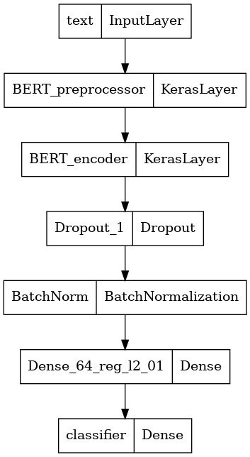

```python
#@title Model summary

print(model.summary())
tf.keras.utils.plot_model(model)
```

```python
# 使用模型对测试文本进行预测
bert_raw_result = model(tf.constant(text_test))
# 对输出结果应用sigmoid激活函数，得到每个类别的概率
classification = tf.sigmoid(bert_raw_result)
# 将概率最高的类别索引转换回原始标签
clazz = le.inverse_transform([np.argmax(classification.numpy())])[0]
# 获取该类别的概率值
weight = classification.numpy()[0][np.argmax(classification.numpy())]
print(f"The classification of {text_test} is {clazz} with weight {weight:,.2f}")
```

```
The classification of ['The system shall refresh the display every 60 seconds.'] is MN with weight 0.59
```

## Training the model (standard Python)

### Model reporting metrics

```python
#@title Training parameters
configs = dict(
    num_classes = num_classes,
    batch_size = 32,
    earlystopping_patience = 3,
    learning_rate = 2e-4,
    epochs = 10,
    num_steps = 0.7,
)
```

```python
# 定义 balanced_recall 指标函数，用于计算多分类任务中每个类别的召回率，并返回类别平均召回率
from keras import backend as K
# https://towardsdatascience.com/multi-label-text-classification-using-bert-and-tensorflow-d2e88d8f488d
def balanced_recall(y_true, y_pred):
    """This function calculates the balanced recall metric
    recall = TP / (TP + FN)
    """
    recall_by_class = 0
    # iterate over each predicted class to get class-specific metric
    for i in range(y_pred.shape[1]):
        y_pred_class = y_pred[:, i]
        y_true_class = y_true[:, i]
        true_positives = K.sum(K.round(K.clip(y_true_class * y_pred_class, 0, 1)))
        possible_positives = K.sum(K.round(K.clip(y_true_class, 0, 1)))
        recall = true_positives / (possible_positives + K.epsilon())
        recall_by_class = recall_by_class + recall
    return recall_by_class / y_pred.shape[1]
```

```python
# 定义 balanced_precision 指标函数，用于计算多分类任务中每个类别的精确率，并返回类别平均精确率
def balanced_precision(y_true, y_pred):
    """This function calculates the balanced precision metric
    precision = TP / (TP + FP)
    """
    precision_by_class = 0
    # iterate over each predicted class to get class-specific metric
    for i in range(y_pred.shape[1]):
        y_pred_class = y_pred[:, i]
        y_true_class = y_true[:, i]
        true_positives = K.sum(K.round(K.clip(y_true_class * y_pred_class, 0, 1)))
        predicted_positives = K.sum(K.round(K.clip(y_pred_class, 0, 1)))
        precision = true_positives / (predicted_positives + K.epsilon())
        precision_by_class = precision_by_class + precision
    # return average balanced metric for each class
    return precision_by_class / y_pred.shape[1]
```

```python
# 定义 balanced_f1_score 指标函数，用于计算多分类任务中每个类别的 F1 分数，并返回类别平均 F1 分数
def balanced_f1_score(y_true, y_pred):
    """This function calculates the F1 score metric"""
    precision = balanced_precision(y_true, y_pred)
    recall = balanced_recall(y_true, y_pred)
    return 2 * ((precision * recall) / (precision + recall + K.epsilon()))

METRICS = [
      tf.keras.metrics.CategoricalAccuracy(name="accuracy"),
      balanced_recall,
      balanced_precision,
      balanced_f1_score
]
```

```python
# 该函数用于输出交叉验证的模型评估结果摘要（均值和标准差）
def cv_summary(scores: pd.DataFrame):
  print("Summary of the cross validate epoch scores.")
  print(f"{'':<15.15}", end='')
  for n in scores.columns:
      print(f"{n:<15.14}", end='')
  print()
  values = list(scores[scores.columns].mean())
  print(f"{'mean':<15}", end='')
  for v in values:
    print(f"{v:<15,.4f}", end='')
  print()
  values = list(scores[scores.columns].std())
  print(f"{'std':<15}", end='')
  for v in values:
    print(f"{v:<15,.4f}", end='')
  print()


# 该函数用于评估模型在测试集上的表现，并输出每个指标的得分
def model_scores(model, X_test, Y_test, verbose=0):
    scores = model.evaluate(X_test, Y_test, verbose=verbose)
    # Output various summaries
    for n,v in zip(model.metrics_names, scores):
      print(f"{n}={v*100:,.3f}%, ",  end='')
    print()
    return scores
```

```python
# 输出模型分类报告，包括精确率、召回率、F1分数等指标
from sklearn.metrics import classification_report

def report_classifications(model: tf.keras.Model, X: pd.Series, Y: pd.Series, num_classes: int):
  Y_pred = np.argmax(model.predict(X), axis=1)
  Y_true = np.argmax(tf.keras.utils.to_categorical(Y, num_classes=num_classes), axis=1)
  print("Summary of classifications")
  print(classification_report(Y_true, Y_pred))
```

```python
def epoch_metrics(model_fit):
  metric_list = list(model_fit.history.keys())
  num_metrics = int(len(metric_list)/2)
  epochs_completed = len(model_fit.history[metric_list[0]])
  x = list(range(1, epochs_completed+1))

  fig, ax = plt.subplots(nrows=1, ncols=num_metrics, figsize=(30, 5))

  for i in range(0, num_metrics):
    ax[i].plot(x, model_fit.history[metric_list[i]], marker="o", label=metric_list[i].replace("_", " "))
    ax[i].plot(x, model_fit.history[metric_list[i+num_metrics]], marker="o", label=metric_list[i+num_metrics].replace("_", " "))
    ax[i].set_xlabel("epochs",fontsize=14)
    ax[i].set_title(metric_list[i].replace("_", " "),fontsize=20)
    ax[i].legend(loc="lower left")

  plt.show()
```

```python
#@title Model cross validation (standard training)

from sklearn.model_selection import StratifiedKFold
from sklearn.model_selection import train_test_split

# 添加 EarlyStopping 回调，用于在验证集损失不再提升时提前终止训练，防止过拟合
earlystop_callback = tf.keras.callbacks.EarlyStopping(monitor = "val_loss",
                                                      patience = configs['earlystopping_patience'],
                                                      restore_best_weights = True)

# 交叉验证和训练相关的辅助函数已在前面定义，包括：
# - model_scores: 用于评估模型在测试集上的表现
# - cv_summary: 用于输出交叉验证的均值和标准差
# - report_classifications: 用于输出分类报告
# - epoch_metrics: 用于绘制训练过程中的指标变化曲线
def cross_validate_model(model: tf.keras.Model, X: pd.Series, Y: pd.Series, num_classes: int, epochs: int, batch_size: int, n_folds=2, graph_scores=True):
  # fix random seed for reproducibility
  seed = 7
  np.random.seed(seed)

  cvscores = []
  if n_folds>1:
    # define n-fold cross validation test harness
    # maximum folds is minimum class count--class with only 1 record -> only 1 fold
    kfold = StratifiedKFold(n_splits=n_folds, shuffle=True, random_state=seed)
    for train, test in kfold.split(X, Y):
      print(f"Processing fold: {len(cvscores)+1}")
      # selected data folds
      Ytrain = tf.keras.utils.to_categorical(Y.iloc[train], num_classes=num_classes)
      Ytest = tf.keras.utils.to_categorical(Y.iloc[test], num_classes=num_classes)
      # fit the model
      model_fit = model.fit(X.iloc[train], Ytrain,
                            epochs=epochs, batch_size=batch_size,
                            class_weight= class_weights,
                            validation_data = (X.iloc[test], Ytest),
                            callbacks = [earlystop_callback])
      # evaluate the model using Keras (validate custom metrics)
      scores = model_scores(model, X.iloc[test], Ytest, verbose=0)
      cvscores.append(scores)
      if graph_scores:
        epoch_metrics(model_fit)
  else:
    print(f"Processing without folds")
    X_train, X_test, y_train, y_test = train_test_split(X, Y, test_size=0.25, random_state=seed)
    Ytrain = tf.keras.utils.to_categorical(y_train, num_classes=num_classes)
    Ytest = tf.keras.utils.to_categorical(y_test, num_classes=num_classes)
    # fit the model
    model_fit = model.fit(X_train, Ytrain,
                          epochs=epochs, batch_size=batch_size,
                          class_weight= class_weights,
                          validation_data = (X_test, Ytest),
                          callbacks = [earlystop_callback])
    # evaluate the model using Keras (validate custom metrics)
    scores = model_scores(model, X_test, Ytest, verbose=0)
    cvscores.append(scores)
    epoch_metrics(model_fit)

  pdf = pd.DataFrame(cvscores, columns = model.metrics_names)
  print()
  cv_summary(pdf)
  print()
  print("Final classifier")
  report_classifications(model, X, Y, num_classes)
  return model_fit, cvscores
```

## Training parameters

```python
#@title Training parameters
# 训练参数配置字典，包括类别数、批量大小、早停轮数、学习率、训练轮数等
configs = dict(
    num_classes = num_classes,
    batch_size = 32,
    earlystopping_patience = 3,
    learning_rate = 2e-4,
    epochs = 10,
    num_steps = 0.7,
)
```

```python
total_steps = len(data)*configs["epochs"]
decay_steps = total_steps * configs["num_steps"]

# tf.keras.optimizers.schedules.CosineDecay 是 TensorFlow 提供的一种学习率衰减策略。
# 它会在训练过程中按照余弦函数曲线逐步降低学习率，有助于模型更好地收敛。
# 余弦衰减适合深度学习训练后期微调，能有效避免陷入局部最优。
cosine_decay_scheduler = tf.keras.optimizers.schedules.CosineDecay(
    initial_learning_rate = configs["learning_rate"],
    decay_steps = decay_steps,
    alpha=0.005
)
# keras.losses.CategoricalCrossentropy 是用于多分类任务的损失函数。
loss_func = keras.losses.CategoricalCrossentropy(from_logits=False)
# tf.keras.optimizers.AdamW 是 TensorFlow 提供的带权重衰减（Weight Decay）的 Adam 优化器。
optimizer = tf.keras.optimizers.AdamW(cosine_decay_scheduler)
# model.compile 用于配置模型的训练过程，包括优化器、损失函数和评估指标。
model.compile(
    optimizer = optimizer,
    loss = loss_func,
    metrics = METRICS
)
```

## Run model (standard training)

```
Processing fold: 1
```

[output not shown]

[output cut: 5468 more lines]

```
loss=203.091%, accuracy=73.118%, balanced_recall=56.194%, balanced_precision=68.079%, balanced_f1_score=61.311%,
```

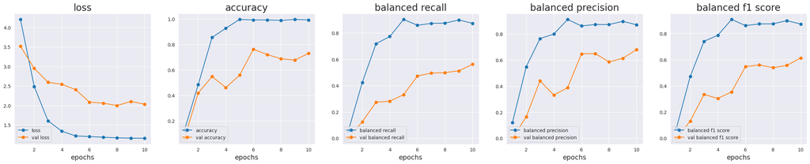

```
Processing fold: 2
loss=134.515%, accuracy=92.391%, balanced_recall=78.167%, balanced_precision=79.802%, balanced_f1_score=78.965%,
```

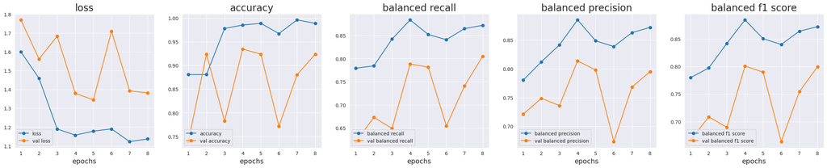

```
Processing fold: 3
loss=123.472%, accuracy=96.739%, balanced_recall=84.444%, balanced_precision=85.000%, balanced_f1_score=84.709%,
```

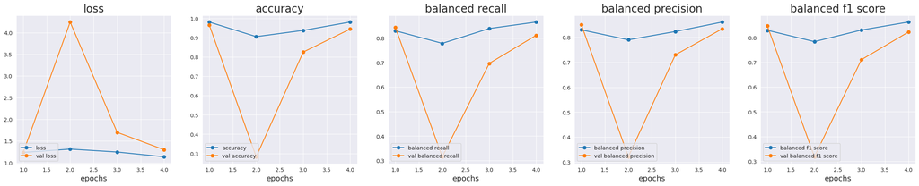

```
Processing fold: 4
loss=106.736%, accuracy=97.826%, balanced_recall=85.000%, balanced_precision=86.190%, balanced_f1_score=85.589%,
```

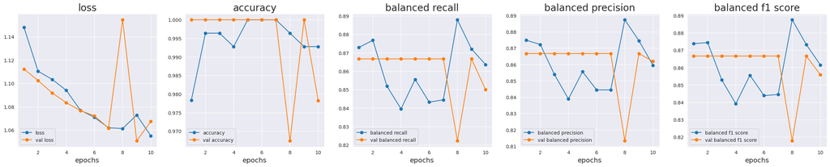

```
Summary of the cross validate epoch scores.
               loss           accuracy       balanced_recal balanced_preci balanced_f1_sc
mean           1.4195         0.9002         0.7595         0.7977         0.7764
std            0.4233         0.1151         0.1353         0.0827         0.1128

Final classifier
Summary of classifications
              precision    recall  f1-score   support

           0       1.00      1.00      1.00        21
           1       1.00      1.00      1.00        10
           2       1.00      1.00      1.00        13
           3       0.97      1.00      0.99        38
           4       0.94      1.00      0.97        17
           5       1.00      0.98      0.99        62
           6       1.00      1.00      1.00        54
           7       1.00      1.00      1.00        21
           8       1.00      1.00      1.00        66
           9       1.00      0.99      0.99        67

    accuracy                           0.99       369
   macro avg       0.99      1.00      0.99       369
weighted avg       0.99      0.99      0.99       369
```

```python
 # 使用标准训练方式进行4折交叉验证，并输出每折的训练过程和评估指标
model_fit, cvscores = cross_validate_model(model, X['text'], Y, configs['num_classes'], configs['epochs'], configs['batch_size'], n_folds=4, graph_scores=True)
```

## Predict with model

```python
# 准备待分类的文本列表（单条文本也要放入列表）
bad_text = ["This is new text is not a requirement."]

# 将 Python 列表转换为 TensorFlow 字符串常量并传入模型，得到原始输出张量
bert_raw_result = model(tf.constant(bad_text))

# 对模型输出应用 sigmoid 激活以得到概率分布
# 注意：若模型最后一层已是 softmax，则再用 sigmoid 可能不必要或不正确
classification = tf.sigmoid(bert_raw_result)

# 将概率向量转换为预测类别索引（取概率最大的位置）
pred_idx = np.argmax(classification.numpy())

# 把索引转换回原始类别标签（LabelEncoder 的 inverse_transform 接受可迭代对象）
clazz = le.inverse_transform([pred_idx])[0]

# 取得预测类别的概率值
weight = classification.numpy()[0][pred_idx]

# 输出结果（格式化概率为两位小数）
print(f"The classification of {bad_text} is {clazz} with weight {weight:,.2f}")
```

```
The classification of ['This is new text is not a requirement.'] is MN with weight 0.60
```

## Spark model training (Horovod)

现在，使用 Horovod 在 Spark 上运行 TensorFlow 训练流程。

```
pip install pyspark==3.2.1 findspark
```

```python
# 初始化 Spark 环境并创建 SparkSession
import findspark
findspark.init()
from pyspark.sql import SparkSession

spark = SparkSession.builder\
        .master("local[*]")\
        .appName("mylab")\
        .config('spark.ui.port', '4050')\
        .getOrCreate()
print(f"Spark version: {spark.version}")
```

[output not shown]

```
Spark version: 3.2.1
```

```python
# 将 pandas DataFrame 转换为 Spark DataFrame，指定列名为 'text' 和 'label'
df = spark.createDataFrame(data, schema=['text', 'label'])
df.show()
```

```
+--------------------+-----+
|                text|label|
+--------------------+-----+
|The system shall ...|    6|
|The application s...|    3|
| If projected  th...|    9|
| The product shal...|    0|
| If projected  th...|    9|
|The product shall...|    8|
|The product shall...|    9|
|The product shall...|    6|
|The look and feel...|    3|
| The user interfa...|    3|
|The system shall ...|    3|
|The product shall...|    3|
|The system shall ...|    9|
|The system shall ...|    9|
|The product shall...|    9|
|The product shall...|    9|
|The product shall...|    6|
|The search result...|    6|
|The product shall...|    6|
|The CMA report sh...|    6|
+--------------------+-----+
only showing top 20 rows
```

```python
# 随机划分
train_df, test_df = df.randomSplit([0.8, 0.2])

train_df.show(3)
```

```
+--------------------+-----+
|                text|label|
+--------------------+-----+
| If projected  th...|    9|
| If projected  th...|    9|
| The product shal...|    0|
+--------------------+-----+
only showing top 3 rows
```

```python
from pyspark.ml.feature import OneHotEncoder
# 将标签列 'label' 进行 one-hot 编码，得到新的特征列 'label_vec'
oh_encoder = OneHotEncoder(inputCols=['label'],
                        outputCols=['label_vec'],
                        dropLast=False)
# 拟合 OneHotEncoder 模型以便将标签列转换为 one-hot 编码
oh_encoder_model = oh_encoder.fit(df)
encoded_df = oh_encoder_model.transform(df)

#划分训练测试集
train_df, test_df = encoded_df.randomSplit([0.8, 0.2])

train_df.show(3)
```

```
+--------------------+-----+--------------+
|                text|label|     label_vec|
+--------------------+-----+--------------+
| If projected  th...|    9|(10,[9],[1.0])|
| If projected  th...|    9|(10,[9],[1.0])|
| The product shal...|    0|(10,[0],[1.0])|
+--------------------+-----+--------------+
only showing top 3 rows
```

```python
# 安装 Horovod Spark 以支持分布式深度学习训练
%pip install -q -U horovod[spark]==0.27.0
```

```python
import horovod
from importlib.metadata import version

print(f"horovod {version('horovod')}")
print(f"keras {version('keras')}")
```

```
horovod 0.28.1
keras 2.12.0
```

## Horovod 模型拟合方法

- 请务必选择较小的模型，否则很容易出现内存溢出错误（OOM）。
  - 例如：选择 small_bert/bert_en_uncased_L-2_H-128_A-2

```python
# 选择用于微调的 BERT 预训练模型名称
# bert_model_name 变量用于指定要加载的 BERT 模型，可以根据任务需求选择不同规模的模型。
# map_name_to_handle 字典将模型名称映射到其在 TensorFlow Hub 上的下载地址，便于后续加载和使用。
# bert_model_name = 'small_bert/bert_en_uncased_L-2_H-512_A-8'
bert_model_name = 'small_bert/bert_en_uncased_L-2_H-128_A-2'  #@param ["bert_en_uncased_L-12_H-768_A-12", "bert_en_cased_L-12_H-768_A-12", "bert_multi_cased_L-12_H-768_A-12", "small_bert/bert_en_uncased_L-2_H-128_A-2", "small_bert/bert_en_uncased_L-2_H-256_A-4", "small_bert/bert_en_uncased_L-2_H-512_A-8", "small_bert/bert_en_uncased_L-2_H-768_A-12", "small_bert/bert_en_uncased_L-4_H-128_A-2", "small_bert/bert_en_uncased_L-4_H-256_A-4", "small_bert/bert_en_uncased_L-4_H-512_A-8", "small_bert/bert_en_uncased_L-4_H-768_A-12", "small_bert/bert_en_uncased_L-6_H-128_A-2", "small_bert/bert_en_uncased_L-6_H-256_A-4", "small_bert/bert_en_uncased_L-6_H-512_A-8", "small_bert/bert_en_uncased_L-6_H-768_A-12", "small_bert/bert_en_uncased_L-8_H-128_A-2", "small_bert/bert_en_uncased_L-8_H-256_A-4", "small_bert/bert_en_uncased_L-8_H-512_A-8", "small_bert/bert_en_uncased_L-8_H-768_A-12", "small_bert/bert_en_uncased_L-10_H-128_A-2", "small_bert/bert_en_uncased_L-10_H-256_A-4", "small_bert/bert_en_uncased_L-10_H-512_A-8", "small_bert/bert_en_uncased_L-10_H-768_A-12", "small_bert/bert_en_uncased_L-12_H-128_A-2", "small_bert/bert_en_uncased_L-12_H-256_A-4", "small_bert/bert_en_uncased_L-12_H-512_A-8", "small_bert/bert_en_uncased_L-12_H-768_A-12", "albert_en_base", "electra_small", "electra_base", "experts_pubmed", "experts_wiki_books", "talking-heads_base"]

map_name_to_handle = {
    'bert_en_uncased_L-12_H-768_A-12':
        'https://tfhub.dev/tensorflow/bert_en_uncased_L-12_H-768_A-12/3',
    'bert_en_cased_L-12_H-768_A-12':
        'https://tfhub.dev/tensorflow/bert_en_cased_L-12_H-768_A-12/3',
    'bert_multi_cased_L-12_H-768_A-12':
        'https://tfhub.dev/tensorflow/bert_multi_cased_L-12_H-768_A-12/3',
    'small_bert/bert_en_uncased_L-2_H-128_A-2':
        'https://tfhub.dev/tensorflow/small_bert/bert_en_uncased_L-2_H-128_A-2/1',
    'small_bert/bert_en_uncased_L-2_H-256_A-4':
        'https://tfhub.dev/tensorflow/small_bert/bert_en_uncased_L-2_H-256_A-4/1',
    'small_bert/bert_en_uncased_L-2_H-512_A-8':
        'https://tfhub.dev/tensorflow/small_bert/bert_en_uncased_L-2_H-512_A-8/1',
    'small_bert/bert_en_uncased_L-2_H-768_A-12':
        'https://tfhub.dev/tensorflow/small_bert/bert_en_uncased_L-2_H-768_A-12/1',
    'small_bert/bert_en_uncased_L-4_H-128_A-2':
        'https://tfhub.dev/tensorflow/small_bert/bert_en_uncased_L-4_H-128_A-2/1',
    'small_bert/bert_en_uncased_L-4_H-256_A-4':
        'https://tfhub.dev/tensorflow/small_bert/bert_en_uncased_L-4_H-256_A-4/1',
    'small_bert/bert_en_uncased_L-4_H-512_A-8':
        'https://tfhub.dev/tensorflow/small_bert/bert_en_uncased_L-4_H-512_A-8/1',
    'small_bert/bert_en_uncased_L-4_H-768_A-12':
        'https://tfhub.dev/tensorflow/small_bert/bert_en_uncased_L-4_H-768_A-12/1',
    'small_bert/bert_en_uncased_L-6_H-128_A-2':
        'https://tfhub.dev/tensorflow/small_bert/bert_en_uncased_L-6_H-128_A-2/1',
    'small_bert/bert_en_uncased_L-6_H-256_A-4':
        'https://tfhub.dev/tensorflow/small_bert/bert_en_uncased_L-6_H-256_A-4/1',
    'small_bert/bert_en_uncased_L-6_H-512_A-8':
        'https://tfhub.dev/tensorflow/small_bert/bert_en_uncased_L-6_H-512_A-8/1',
    'small_bert/bert_en_uncased_L-6_H-768_A-12':
        'https://tfhub.dev/tensorflow/small_bert/bert_en_uncased_L-6_H-768_A-12/1',
    'small_bert/bert_en_uncased_L-8_H-128_A-2':
        'https://tfhub.dev/tensorflow/small_bert/bert_en_uncased_L-8_H-128_A-2/1',
    'small_bert/bert_en_uncased_L-8_H-256_A-4':
        'https://tfhub.dev/tensorflow/small_bert/bert_en_uncased_L-8_H-256_A-4/1',
    'small_bert/bert_en_uncased_L-8_H-512_A-8':
        'https://tfhub.dev/tensorflow/small_bert/bert_en_uncased_L-8_H-512_A-8/1',
    'small_bert/bert_en_uncased_L-8_H-768_A-12':
        'https://tfhub.dev/tensorflow/small_bert/bert_en_uncased_L-8_H-768_A-12/1',
    'small_bert/bert_en_uncased_L-10_H-128_A-2':
        'https://tfhub.dev/tensorflow/small_bert/bert_en_uncased_L-10_H-128_A-2/1',
    'small_bert/bert_en_uncased_L-10_H-256_A-4':
        'https://tfhub.dev/tensorflow/small_bert/bert_en_uncased_L-10_H-256_A-4/1',
    'small_bert/bert_en_uncased_L-10_H-512_A-8':
        'https://tfhub.dev/tensorflow/small_bert/bert_en_uncased_L-10_H-512_A-8/1',
    'small_bert/bert_en_uncased_L-10_H-768_A-12':
        'https://tfhub.dev/tensorflow/small_bert/bert_en_uncased_L-10_H-768_A-12/1',
    'small_bert/bert_en_uncased_L-12_H-128_A-2':
        'https://tfhub.dev/tensorflow/small_bert/bert_en_uncased_L-12_H-128_A-2/1',
    'small_bert/bert_en_uncased_L-12_H-256_A-4':
        'https://tfhub.dev/tensorflow/small_bert/bert_en_uncased_L-12_H-256_A-4/1',
    'small_bert/bert_en_uncased_L-12_H-512_A-8':
        'https://tfhub.dev/tensorflow/small_bert/bert_en_uncased_L-12_H-512_A-8/1',
    'small_bert/bert_en_uncased_L-12_H-768_A-12':
        'https://tfhub.dev/tensorflow/small_bert/bert_en_uncased_L-12_H-768_A-12/1',
    'albert_en_base':
        'https://tfhub.dev/tensorflow/albert_en_base/2',
    'electra_small':
        'https://tfhub.dev/google/electra_small/2',
    'electra_base':
        'https://tfhub.dev/google/electra_base/2',
    'experts_pubmed':
        'https://tfhub.dev/google/experts/bert/pubmed/2',
    'experts_wiki_books':
        'https://tfhub.dev/google/experts/bert/wiki_books/2',
    'talking-heads_base':
        'https://tfhub.dev/tensorflow/talkheads_ggelu_bert_en_base/1',
}
```

```python
# 根据所选 BERT 预训练模型自动选择对应的预处理模型（preprocess model）URL
# 这样可以确保文本输入经过与 BERT 模型兼容的分词和编码处理

map_model_to_preprocess = {
    'bert_en_uncased_L-12_H-768_A-12':
        'https://tfhub.dev/tensorflow/bert_en_uncased_preprocess/3',
    'bert_en_cased_L-12_H-768_A-12':
        'https://tfhub.dev/tensorflow/bert_en_cased_preprocess/3',
    'small_bert/bert_en_uncased_L-2_H-128_A-2':
        'https://tfhub.dev/tensorflow/bert_en_uncased_preprocess/3',
    'small_bert/bert_en_uncased_L-2_H-256_A-4':
        'https://tfhub.dev/tensorflow/bert_en_uncased_preprocess/3',
    'small_bert/bert_en_uncased_L-2_H-512_A-8':
        'https://tfhub.dev/tensorflow/bert_en_uncased_preprocess/3',
    'small_bert/bert_en_uncased_L-2_H-768_A-12':
        'https://tfhub.dev/tensorflow/bert_en_uncased_preprocess/3',
    'small_bert/bert_en_uncased_L-4_H-128_A-2':
        'https://tfhub.dev/tensorflow/bert_en_uncased_preprocess/3',
    'small_bert/bert_en_uncased_L-4_H-256_A-4':
        'https://tfhub.dev/tensorflow/bert_en_uncased_preprocess/3',
    'small_bert/bert_en_uncased_L-4_H-512_A-8':
        'https://tfhub.dev/tensorflow/bert_en_uncased_preprocess/3',
    'small_bert/bert_en_uncased_L-4_H-768_A-12':
        'https://tfhub.dev/tensorflow/bert_en_uncased_preprocess/3',
    'small_bert/bert_en_uncased_L-6_H-128_A-2':
        'https://tfhub.dev/tensorflow/bert_en_uncased_preprocess/3',
    'small_bert/bert_en_uncased_L-6_H-256_A-4':
        'https://tfhub.dev/tensorflow/bert_en_uncased_preprocess/3',
    'small_bert/bert_en_uncased_L-6_H-512_A-8':
        'https://tfhub.dev/tensorflow/bert_en_uncased_preprocess/3',
    'small_bert/bert_en_uncased_L-6_H-768_A-12':
        'https://tfhub.dev/tensorflow/bert_en_uncased_preprocess/3',
    'small_bert/bert_en_uncased_L-8_H-128_A-2':
        'https://tfhub.dev/tensorflow/bert_en_uncased_preprocess/3',
    'small_bert/bert_en_uncased_L-8_H-256_A-4':
        'https://tfhub.dev/tensorflow/bert_en_uncased_preprocess/3',
    'small_bert/bert_en_uncased_L-8_H-512_A-8':
        'https://tfhub.dev/tensorflow/bert_en_uncased_preprocess/3',
    'small_bert/bert_en_uncased_L-8_H-768_A-12':
        'https://tfhub.dev/tensorflow/bert_en_uncased_preprocess/3',
    'small_bert/bert_en_uncased_L-10_H-128_A-2':
        'https://tfhub.dev/tensorflow/bert_en_uncased_preprocess/3',
    'small_bert/bert_en_uncased_L-10_H-256_A-4':
        'https://tfhub.dev/tensorflow/bert_en_uncased_preprocess/3',
    'small_bert/bert_en_uncased_L-10_H-512_A-8':
        'https://tfhub.dev/tensorflow/bert_en_uncased_preprocess/3',
    'small_bert/bert_en_uncased_L-10_H-768_A-12':
        'https://tfhub.dev/tensorflow/bert_en_uncased_preprocess/3',
    'small_bert/bert_en_uncased_L-12_H-128_A-2':
        'https://tfhub.dev/tensorflow/bert_en_uncased_preprocess/3',
    'small_bert/bert_en_uncased_L-12_H-256_A-4':
        'https://tfhub.dev/tensorflow/bert_en_uncased_preprocess/3',
    'small_bert/bert_en_uncased_L-12_H-512_A-8':
        'https://tfhub.dev/tensorflow/bert_en_uncased_preprocess/3',
    'small_bert/bert_en_uncased_L-12_H-768_A-12':
        'https://tfhub.dev/tensorflow/bert_en_uncased_preprocess/3',
    'bert_multi_cased_L-12_H-768_A-12':
        'https://tfhub.dev/tensorflow/bert_multi_cased_preprocess/3',
    'albert_en_base':
        'https://tfhub.dev/tensorflow/albert_en_preprocess/3',
    'electra_small':
        'https://tfhub.dev/tensorflow/bert_en_uncased_preprocess/3',
    'electra_base':
        'https://tfhub.dev/tensorflow/bert_en_uncased_preprocess/3',
    'experts_pubmed':
        'https://tfhub.dev/tensorflow/bert_en_uncased_preprocess/3',
    'experts_wiki_books':
        'https://tfhub.dev/tensorflow/bert_en_uncased_preprocess/3',
    'talking-heads_base':
        'https://tfhub.dev/tensorflow/bert_en_uncased_preprocess/3',
}
```

```python
# 根据 bert_model_name 选择合适的编码器和预处理模型句柄
# tfhub_handle_encoder: BERT 主体模型句柄（用于特征提取）
# tfhub_handle_preprocess: BERT 预处理模型句柄（用于分词、编码等）

tfhub_handle_encoder = map_name_to_handle[bert_model_name]
tfhub_handle_preprocess = map_model_to_preprocess[bert_model_name]

print(f'BERT model selected           : {tfhub_handle_encoder}')
print(f'Preprocess model auto-selected: {tfhub_handle_preprocess}')
```

```
BERT model selected           : https://tfhub.dev/tensorflow/small_bert/bert_en_uncased_L-2_H-128_A-2/1
Preprocess model auto-selected: https://tfhub.dev/tensorflow/bert_en_uncased_preprocess/3
```

```python
# 构建一个用于多分类的 BERT 文本分类模型（适用于 Horovod Spark 分布式训练）
# 该模型结构与标准训练类似，包含 BERT 预处理层、BERT 编码器、Dropout、BatchNormalization、全连接层和 softmax 输出层
# 可根据需要调整正则化和归一化层，以适配不同规模的数据和分布式训练环境

def build_model():
  text_input = tf.keras.layers.Input(shape=(), dtype=tf.string, name='text')
  preprocessing_layer = hub.KerasLayer(tfhub_handle_preprocess, name='BERT_preprocessor')
  encoder_inputs = preprocessing_layer(text_input)
  encoder = hub.KerasLayer(tfhub_handle_encoder, trainable=True, name='BERT_encoder')
  outputs = encoder(encoder_inputs)
  net = outputs['pooled_output']
  net = tf.keras.layers.Dropout(0.1, name='Dropout_1')(net)
  net = tf.keras.layers.BatchNormalization(name='BatchNorm')(net)
  # When dropping BatchNorm and regularization to mimic NORBERT, F1 score is similar (82%)
  # net = tf.keras.layers.Dense(64, name='Dense_64')(net)
  net = tf.keras.layers.Dense(64, name='Dense_64_reg_l2_01', kernel_regularizer=tf.keras.regularizers.l2(0.01))(net)
  net = tf.keras.layers.Dense(num_classes, activation='softmax', name="classifier")(net)
  return tf.keras.Model(inputs=text_input, outputs=net, name="req_classifier")

small_model = build_model()
```

[output not shown]

[output cut: 42 more lines]

```python
#@title Train model using Horovod Spark
# 使用 Horovod Spark 的 KerasEstimator 进行分布式训练
# 该方法可在多进程/多节点环境下高效训练深度学习模型，适合大规模数据和模型
# 训练数据需为 Spark DataFrame，特征和标签列需与模型输入匹配

import horovod.spark.keras as hvd

from horovod.spark.common.store import Store
# Setup our store for intermediate data
# Store 用于保存 Horovod Spark 训练过程中的中间数据和模型快照
# 可以选择本地文件系统路径（如 /tmp），也可以配置为远程存储（如 S3、HDFS 等）
store = Store.create("/tmp")


# Custom metrics, like above METRICS, reuqire more code to show with horovod
# Horovod Spark 目前仅支持标准 Keras 指标（如 accuracy、loss），
# 若需自定义指标（如 F1、balanced recall），需自定义回调或后处理，不直接在 estimator 中指定。
# 这里只使用 'accuracy' 作为评估指标，训练后可在本地进行更详细的评估。
small_model.compile(optimizer = optimizer,
                  loss = loss_func,
                  metrics=['accuracy'])

num_proc=2
CUSTOM_OBJECTS = {'KerasLayer':hub.KerasLayer, 'CaseFoldUTF8':text.case_fold_utf8,
                  'AdamW':tf.keras.optimizers.AdamW, 'Adafactor':tf.keras.optimizers.Adafactor,
                  'CosineDecay': tf.keras.optimizers.schedules.CosineDecay}
```

```python
# 使用 Horovod Spark 的 KerasEstimator 进行分布式训练
# - num_proc: 并行进程数（通常等于可用GPU/CPU数量）
# - store: Horovod Spark 用于存储中间数据和模型快照的存储对象
# - model: 构建好的 Keras 模型（small_model）
# - custom_objects: 自定义对象字典，确保模型和优化器等可正确序列化/反序列化
# - optimizer: 优化器（如 AdamW）
# - loss: 损失函数（如 CategoricalCrossentropy）
# - feature_cols: 特征列名（如 'text'）
# - label_cols: 标签列名（如 'label_vec'，需为 one-hot 编码）
# - metrics: 评估指标（如 'accuracy'）
# - batch_size, epochs: 训练批量大小和轮数
# - random_seed: 随机种子，保证实验可复现
# - verbose: 日志详细程度
keras_estimator = hvd.KerasEstimator(
    num_proc=num_proc,
    store=store,
    model=small_model,
    custom_objects=CUSTOM_OBJECTS,
    optimizer=optimizer,
    loss=loss_func,
    feature_cols=['text'],
    label_cols=['label_vec'],
    metrics=['accuracy'],
    batch_size=configs['batch_size'],
    epochs=configs['epochs'],
    random_seed=1,
    verbose=1)

keras_model = keras_estimator.fit(train_df.repartition(num_proc)).setOutputCols(['label_prob'])
```

```
num_partitions=20
writing dataframes
train_data_path=file:///tmp/intermediate_train_data.0
val_data_path=file:///tmp/intermediate_val_data.0
train_partitions=20
```

```
train_rows=294
```

[output not shown]

```
[1,1]<stdout>:An error occurred: module 'importlib.metadata' has no attribute 'packages_distributions'
```

[output not shown]

```
[1,0]<stdout>:An error occurred: module 'importlib.metadata' has no attribute 'packages_distributions'
```

```
[1,0]<stdout>:Pinning current process to the GPU.
```

[output not shown]

```
[1,0]<stdout>:Shared lib path is pointing to: <CDLL '/home/legion/miniconda3/envs/horovod/lib/python3.8/site-packages/horovod/tensorflow/mpi_lib.cpython-38-x86_64-linux-gnu.so', handle 1a4a8740 at 0x7f4eeb009700>
[1,0]<stdout>:Training parameters: Epochs: 10, Scaled lr: 0.00039999998989515007, Shuffle: True, random_seed: 1
[1,0]<stdout>:Train rows: 294, Train batch size: 32, Train_steps_per_epoch: 5
[1,0]<stdout>:Val rows: 0, Val batch size: 32, Val_steps_per_epoch: None
[1,0]<stdout>:Checkpoint file: file:///tmp/runs/keras_1764058101, Logs dir: file:///tmp/runs/keras_1764058101/logs
[1,0]<stdout>:
[1,0]<stdout>:data_module: <class 'horovod.spark.keras.datamodule.PetastormDataModule'>
```

[output not shown]

[output cut: 46 more lines]

```
[1,0]<stdout>:Epoch 1/10
```

```
[legion:29899] 1 more process has sent help message help-btl-vader.txt / cma-permission-denied
[legion:29899] Set MCA parameter "orte_base_help_aggregate" to 0 to see all help / error messages
[1,0]<stderr>:  warnings.warn(_RESET_READER_WARN, category=UserWarning)
[1,1]<stderr>:  warnings.warn(_RESET_READER_WARN, category=UserWarning)
```

```
[1,0]<stdout>:Epoch 2/10
2/5 [=========
```

```
[1,0]<stdout>:Epoch 3/10
1/5 [=====>...
```

```
[1,0]<stdout>:Epoch 4/10
1/5 [=====>...
```

```
[1,0]<stdout>:Epoch 5/10
[1,0]<stdout>:
```

```
[1,0]<stdout>:Epoch 6/10
[1,0]<stdout>:
```

```
[1,0]<stdout>:Epoch 7/10
[1,0]<stdout>:
```

```
[1,0]<stdout>:Epoch 8/10
```

```
[1,0]<stdout>:Epoch 9/10
```

```
4/5 [=========
```

```
[Stage 12:>                                                         (0 + 2) / 2]
```

```
[1,0]<stdout>:Epoch 10/10
```

```python
# 使用 Horovod Spark 训练好的模型对测试集进行预测，并评估准确率

from pyspark.ml.evaluation import MulticlassClassificationEvaluator
from pyspark.sql.functions import udf
import pyspark.sql.types as T

# Evaluate the model on the held-out test DataFrame
pred_df = keras_model.transform(test_df)
argmax = udf(lambda v: float(np.argmax(v)), returnType=T.DoubleType())
pred_df = pred_df.withColumn('label_pred', argmax(pred_df.label_prob))
evaluator = MulticlassClassificationEvaluator(predictionCol='label_pred', labelCol='label', metricName='accuracy')
print('Test accuracy:', evaluator.evaluate(pred_df))
```

[output not shown]

[output cut: 172 more lines]